```r
library('tidyverse')
require(lattice)
```

```r
library("dplyr")
library(pivottabler)
library(ggplot2)
```

```r
df=read_csv("lendingloans1.csv")
df1 <- select(df,c(-funded_amnt,-funded_amnt_inv,-pymnt_plan,-title,-zip_code,-earliest_cr_line,-revol_bal,-revol_util,-out_prncp_inv,-total_pymnt_inv,-total_rec_int,-total_rec_late_fee,-recoveries,
-collection_recovery_fee,-last_credit_pull_d,
-collections_12_mths_ex_med,-policy_code,-tot_coll_amt,-tot_cur_bal
,-last_pymnt_amnt,-next_pymnt_d,-open_acc_6m,-open_act_il,-open_il_12m,-total_bal_il,-il_util,-open_rv_12m,-max_bal_bc,-inq_fi,-total_cu_tl,-last_pymnt_d))
```

```r
df1
```

```
## # A tibble: 200,000 x 39
##    loan_amnt term  int_rate installment grade sub_grade emp_title emp_length
##        <dbl> <chr>    <dbl>       <dbl> <chr> <chr>     <chr>     <chr>
##  1     10200 36 m~    14.1         349. C     C3        coustome~ 2 years
##  2     10400 60 m~    21.4         284  D     D5        Program ~ 2 years
##  3     22000 60 m~    20           583. D     D4        Letter C~ 10+ years
##  4     40000 36 m~     7.97       1253. A     A5        VP        5 years
##  5     21000 36 m~     6.72        646. A     A3        Coordina~ 5 years
##  6     30000 60 m~    10.4         644. B     B3        Project ~ 2 years
##  7     31200 60 m~    20           827. D     D4        Quality ~ 2 years
##  8     10000 36 m~    21.4         379. D     D5        Sr Engin~ < 1 year
##  9     20000 60 m~    19.0         519. D     D3        manager   10+ years
## 10      4200 36 m~    13.6         143. C     C2        Administ~ 10+ years
## # ... with 199,990 more rows, and 31 more variables: home_ownership <chr>,
## #   annual_inc <dbl>, verification_status <chr>, issue_d <chr>,
## #   loan_status <chr>, purpose <chr>, addr_state <chr>, dti <dbl>,
## #   delinq_2yrs <dbl>, inq_last_6mths <dbl>, mths_since_last_delinq <dbl>,
## #   mths_since_last_record <dbl>, open_acc <dbl>, pub_rec <dbl>,
## #   total_acc <dbl>, initial_list_status <chr>, out_prncp <dbl>,
## #   total_pymnt <dbl>, total_rec_prncp <dbl>,
## #   mths_since_last_major_derog <dbl>, application_type <chr>,
## #   annual_inc_joint <dbl>, dti_joint <dbl>, verification_status_joint <chr>,
## #   acc_now_delinq <dbl>, open_il_24m <dbl>, mths_since_rcnt_il <dbl>,
## #   open_rv_24m <dbl>, all_util <dbl>, total_rev_hi_lim <dbl>,
## #   inq_last_12m <dbl>
```

```
 Q1. Customer under which grade have highest and lowest no of loans?
```

```r
table(df1$grade)
```

```
##
##     A     B     C     D     E     F     G
## 50154 55562 53126 30395  9350  1175   238
```

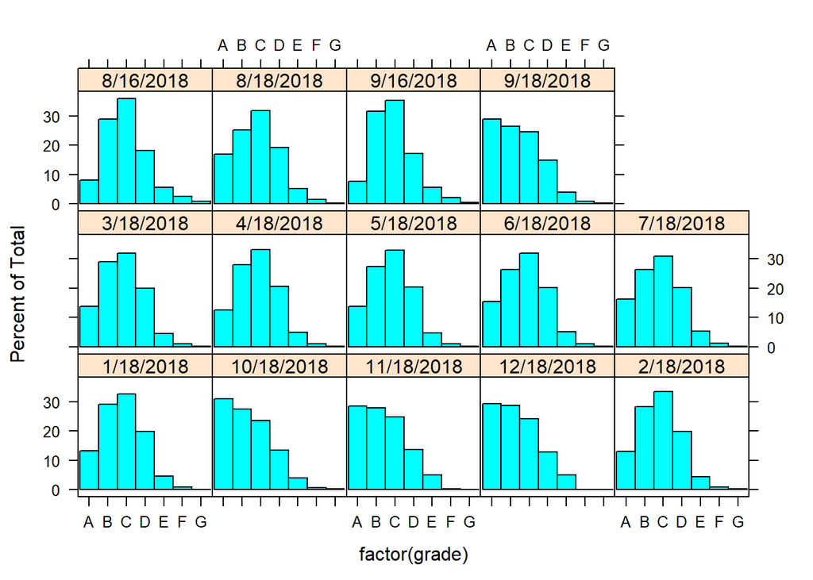

```r
histogram(~factor(grade)|issue_d
,df1)
```

_______________________________________________________________________________________________________________________

[output not shown]

Q2. Which installment term has been opted by the customer?

```r
table(df1$term)
```

```
##
## 36 months 60 months
##    139587     60413
```

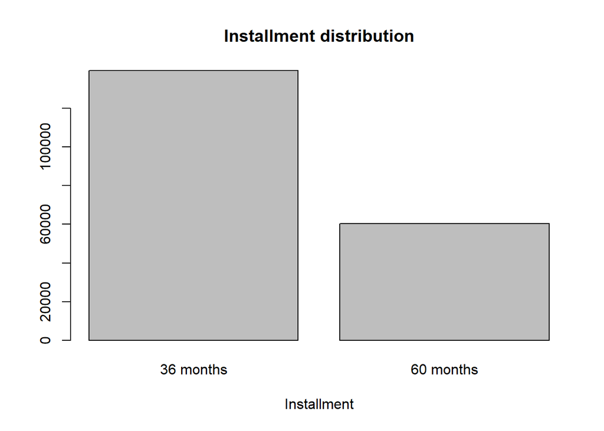

```r
counts <- table(df1$term)
barplot(counts, main="Installment distribution",
   xlab="Installment")
```

From the visualization we observe that customers are more intrested in paying their EMIs or installments in short span of time (36 months)

Q3. What is the range of loan amount variable ? which range of loan amt has higest no of customers ?

```r
summary(df1$loan_amnt)
```

```
##    Min. 1st Qu.  Median    Mean 3rd Qu.    Max.
##    1000    8000   13500   15851   21000   40000
```

loan amount ranges from 1000$-40000$ as per dataset. From the IQR technique , 50 % of the loan distribution is between 8000$-21000$, 25 % of the loan distribution is between 1000-7999 25 % of the loan distribution is between 21001-40000

```r
summary(as.numeric(gsub("%","",df1$int_rate)))
```

```
##    Min. 1st Qu.  Median    Mean 3rd Qu.    Max.
##    5.31    8.81   12.73   13.27   16.14   30.99
```

```r
df1$employ <- NA
df1$employ[df1$emp_length == "n/a"] <- "Unemployed"
df1$employ[df1$emp_length == "< 1 year"] <- "Less than 2 years"
df1$employ[df1$emp_length == "1 year"] <- "Less than 2 years"
df1$employ[df1$emp_length == "2 years"] <- "2-4 years"
df1$employ[df1$emp_length == "3 years"] <- "2-4 years"
df1$employ[df1$emp_length == "4 years"] <- "2-4 years"
df1$employ[df1$emp_length == "5 years"] <- "5-9 years"
df1$employ[df1$emp_length == "6 years"] <- "5-9 years"
df1$employ[df1$emp_length == "7 years"] <- "5-9 years"
df1$employ[df1$emp_length == "8 years"] <- "5-9 years"
df1$employ[df1$emp_length == "9 years"] <- "5-9 years"
df1$employ[df1$emp_length == "10+ years"] <- "10+ years"
df1$employ <- factor(df1$employ,
                      levels = c("Unemployed",
                                 "Less than 2 years",
                                 "2-4 years",
                                 "5-9 years",
                                 "10+ years"))
```

Here, the employee service duration(“emp_length”) is grouped as (Unemployed, Less than 2 years, 2-4 years, 5-9 years, 10+ years) _______________________________________________________________________________________________________________________

Q4. Which customers are taking highest no of loans by length of employment.

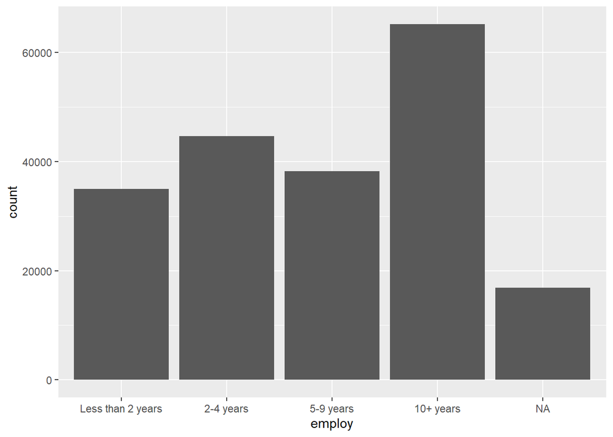

```r
ggplot(data = df1, mapping = aes(x = employ)) +
    geom_bar()
```

_______________________________________________________________________________________________________________________

From the visualization barplot chart, customers with 10+ emmployee service duration(years) have taken highest loans compared to nonsalaried customers.

Here, Loan_Status values are grouped as(Good Loans, Bad Loan based on the description provided by the Lending club dataset.) _______________________________________________________________________________________________________________________

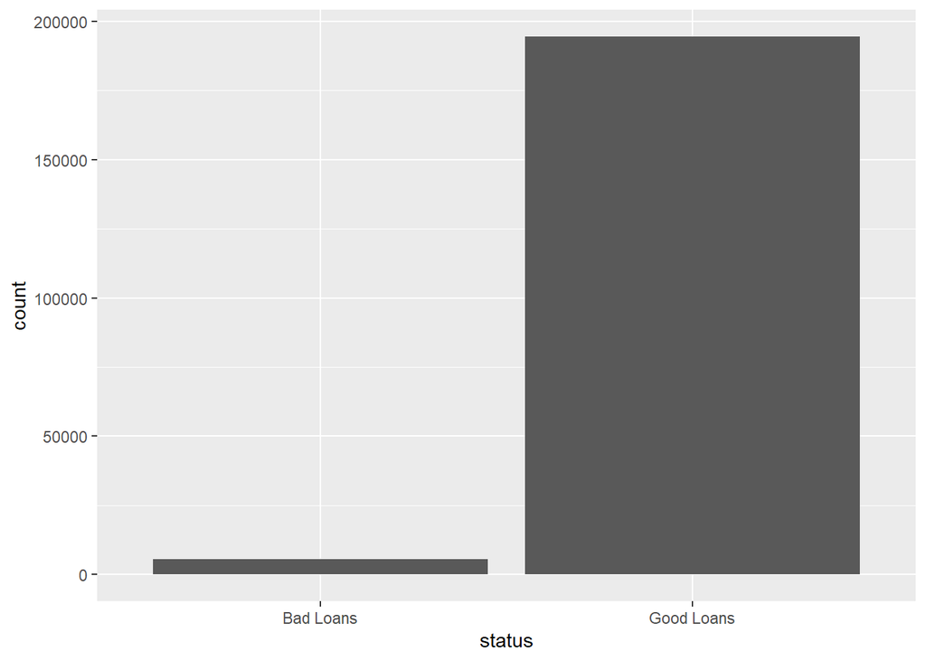

```r
df1$status <- gsub("Does not meet the credit policy. Status:", "", df$loan_status)

df1$status[df1$status == "Current"] <- "Good Loans"
df1$status[df1$status == "Fully Paid"] <- "Good Loans"
df1$status[df1$status == "Fully Paid"] <- "Good Loans"
df1$status[df1$status == "Default"] <- "Bad Loans"


df1$status[df1$status == "Charged Off"] <- "Bad Loans"
df1$status[df1$status == "In Grace Period"] <- "Bad Loans"
df1$status[df1$status == "Late (16-30 days)"] <- "Bad Loans"
df1$status[df1$status == "Late (31-120 days)"] <- "Bad Loans"

ggplot(data=df1, aes(x=status)) +
  geom_bar()
```

_______________________________________________________________________________________________________________________

From the distribution barplot, customers who are paying the installments regularly are very high. (In real world good loans are more than bad loans.)

```r
df1$verification_status[df1$verification_status == "Source Verified"] <- "Verified"
df1$verification_status[df1$verification_status == " Verified"] <- "Verified"
df1$verification_status[df1$verification_status == "Not Verified"] <- "Not Verified"

df1$employ <- factor(df1$verification_status,
                      levels = c("Verified",
                                 "Not Verified"))
```

Here, Verification_status is grouped as verified(Source verified and Verified) and Not verified.

Q5. Based on issue_d variable, Which month has highest no of loan amount?

```r
df2<-df1%>%group_by(issue_d)%>%count()
df2%>%arrange(desc(n))
```

```
## # A tibble: 14 x 2
## # Groups:   issue_d [14]
##    issue_d        n
##    <chr>      <int>
##  1 10/18/2018 46305
##  2 11/18/2018 41973
##  3 12/18/2018 40134
##  4 9/18/2018  16031
##  5 5/18/2018   6954
##  6 8/18/2018   6722
##  7 4/18/2018   6441
##  8 7/18/2018   6383
##  9 9/16/2018   6165
## 10 6/18/2018   6124
## 11 3/18/2018   5565
## 12 1/18/2018   5217
## 13 2/18/2018   4675
## 14 8/16/2018   1311
```

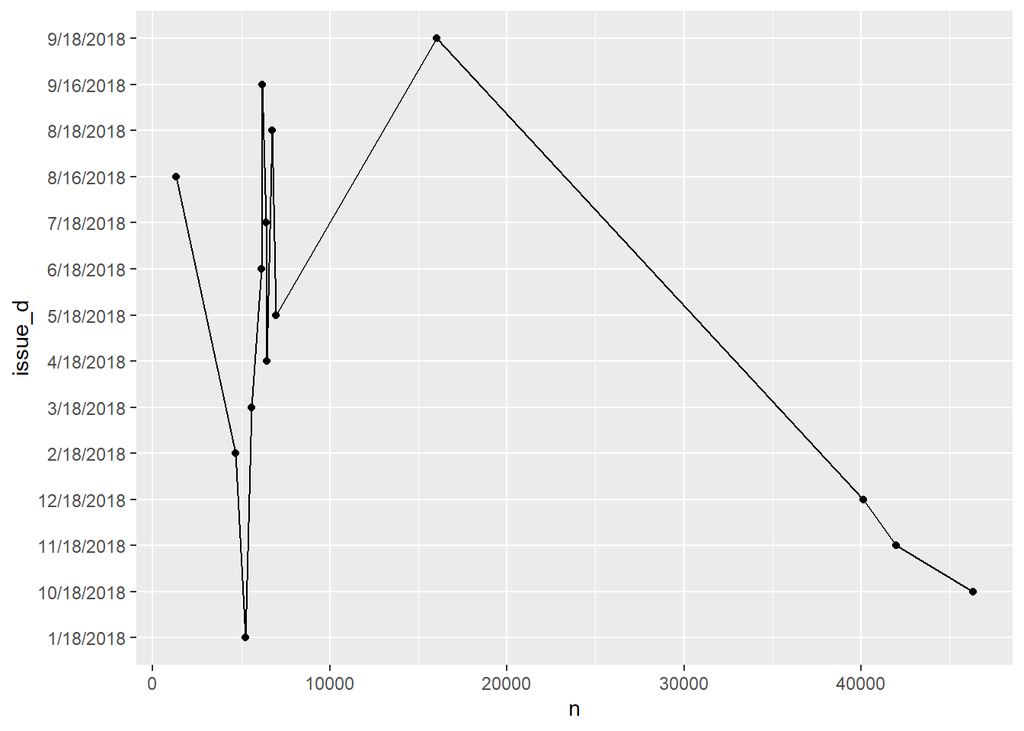

```r
ggplot(data=df2, aes(y=issue_d, x=n,group=1)) +
  geom_line()+
  geom_point()
```

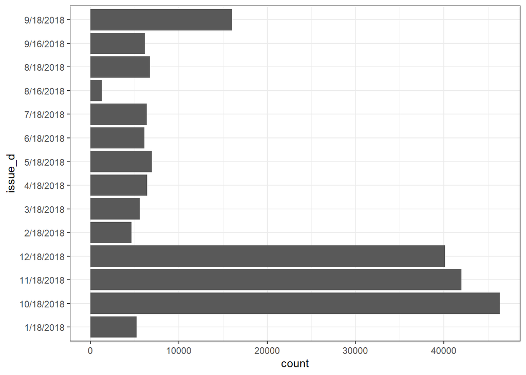

```r
ggplot(df1) + geom_bar(aes(y=issue_d))  + theme_bw()
```

_______________________________________________________________________________________________________________________

```
Most of the loans are being issued in the month of September, October, November and December. From this we
can assume that due to Thanksgiving, Christmas and New Year customers tend to apply for more loans.
```

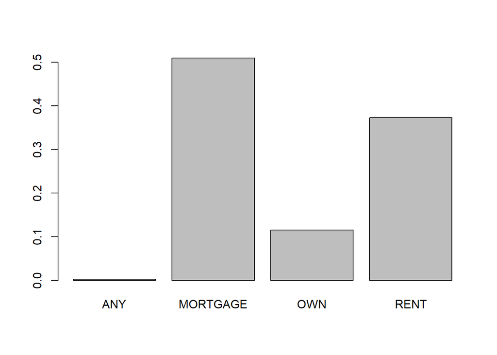

```r
barplot(prop.table(table(df1$home_ownership)))
```

_______________________________________________________________________________________________________________________

```
Here, can say that customers who are having mortgage loans have taken highest no of loans.
```

```
Q6. Does the applicant need to be verified to get a loan?
```

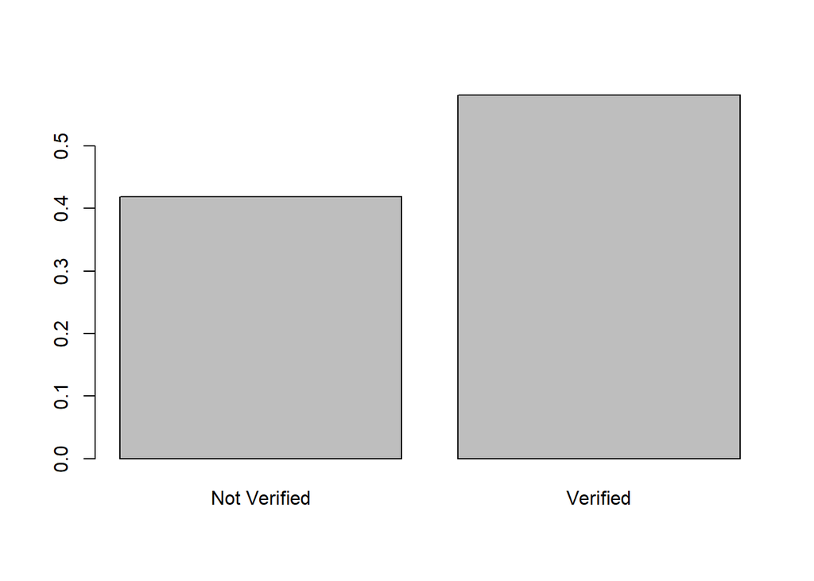

```r
barplot(prop.table(table(df1$verification_status)))
```

```r
table(df1$verification_status)
```

```
##
## Not Verified     Verified
##        83766       116234
```

```
Here, we can see that most of the customers income is verified.
From the Barplot, we can say that the applicant need not to be verified to get a loan.
```

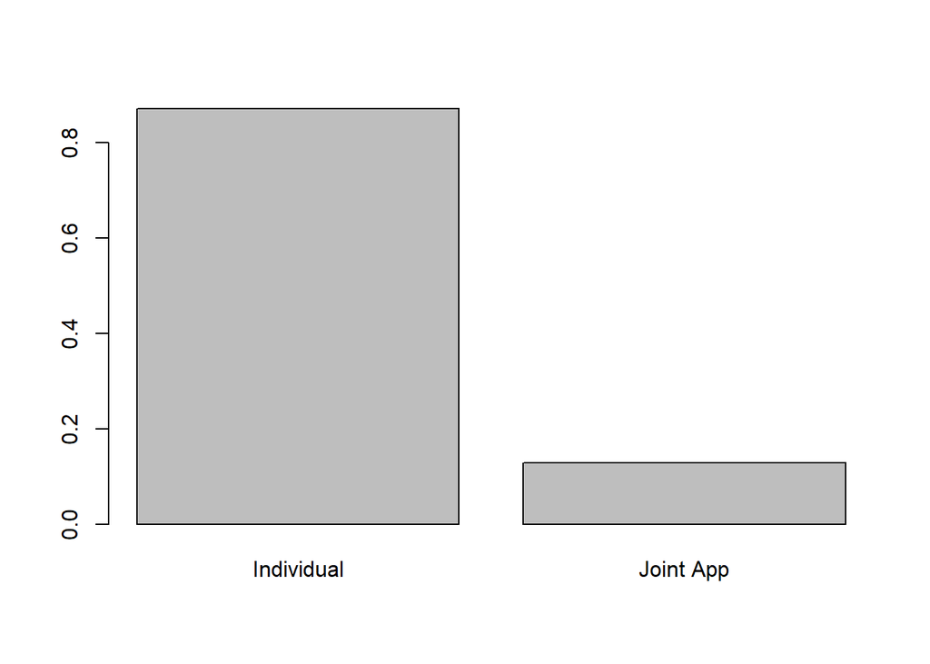

```r
barplot(prop.table(table(df1$application_type)))
```

_______________________________________________________________________________________________________________________

```
  Here, Individual type of applications are more.
```

```
Q6. Which states have taken higher no of loans?
```

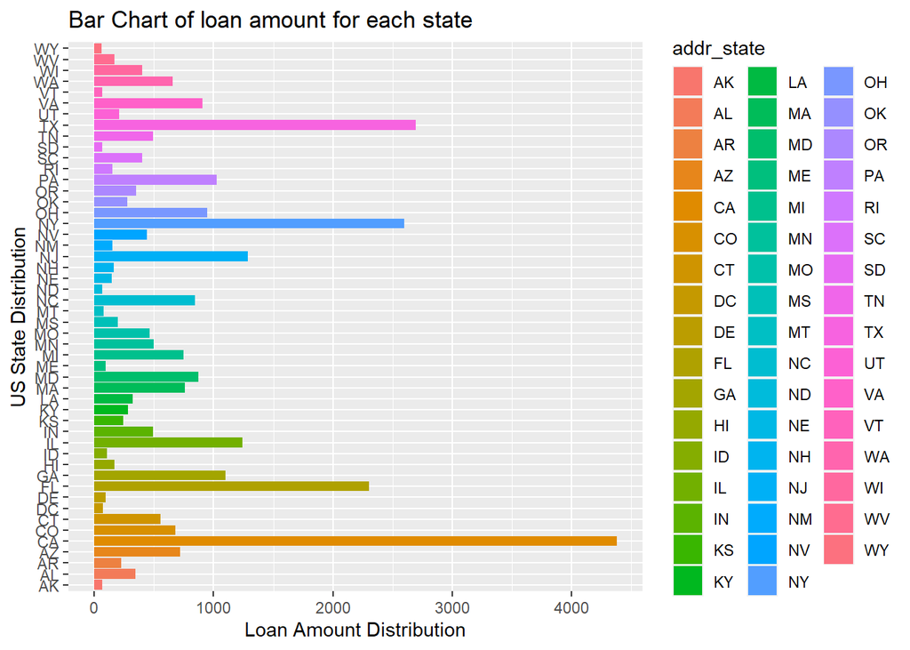

```r
ggplot(data = subset(df1, !is.na(addr_state)), aes(x = addr_state, y = loan_amnt/100000,
    fill = addr_state)) + stat_summary(fun.y = "sum", geom = "bar") + coord_flip() +
    labs(y = "Loan Amount Distribution", x = "US State Distribution", title = "Bar Chart of loan amount for each state")
```

_______________________________________________________________________________________________________________________

```
From the Barplot, we observe that California,Texas and New York have higher no of customers.
```

Q7. How does the loan status effect based on annual income of a customer with respect to grades?

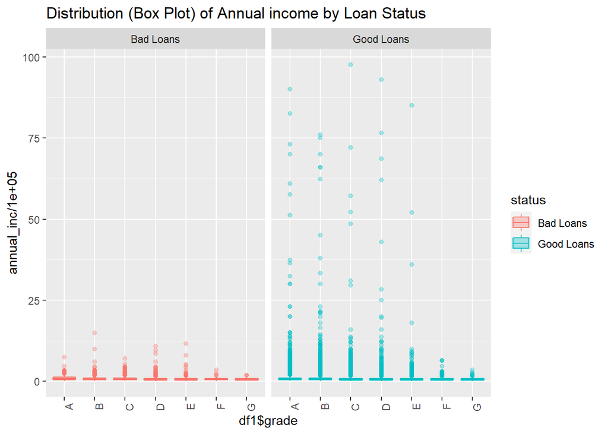

```r
ggplot(data = df1, aes(y = annual_inc/100000, x = df1$grade, fill = status, color = status)) +
    geom_boxplot(alpha = 1/3) + facet_grid(. ~ status) + labs(title = "Distribution (Box Plot) of Annual income by Loan Status") +
    theme(axis.text.x = element_text(angle = 90, hjust = 1))
```

_______________________________________________________________________________________________________________________ From the Boxplot distribution, we observe that the distribution of bad loans income are in fixed ranges with respect to grades compared to good loans, were many outliers are present.

Q8. Which category of home ownership affects the loan status?

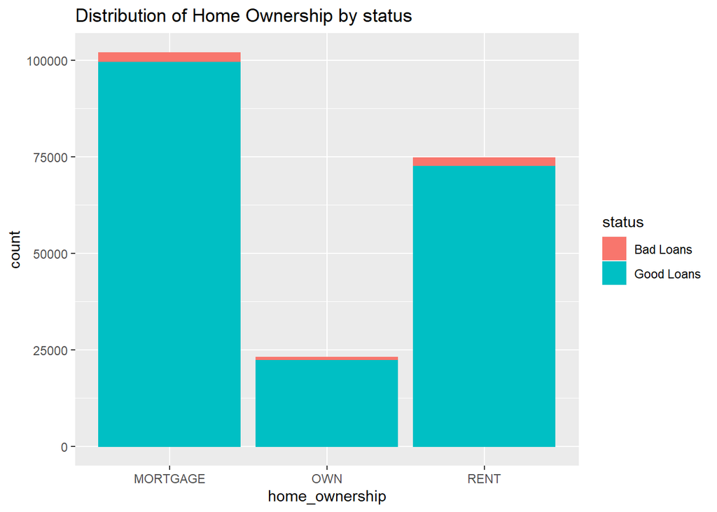

```r
ggplot(data = subset(df1, (!is.na(home_ownership) & (!home_ownership %in% c("ANY",
    "NONE", "OTHER")))), aes(home_ownership, fill = status, color = status)) +
    geom_bar() + labs(title = "Distribution of Home Ownership by status")
```

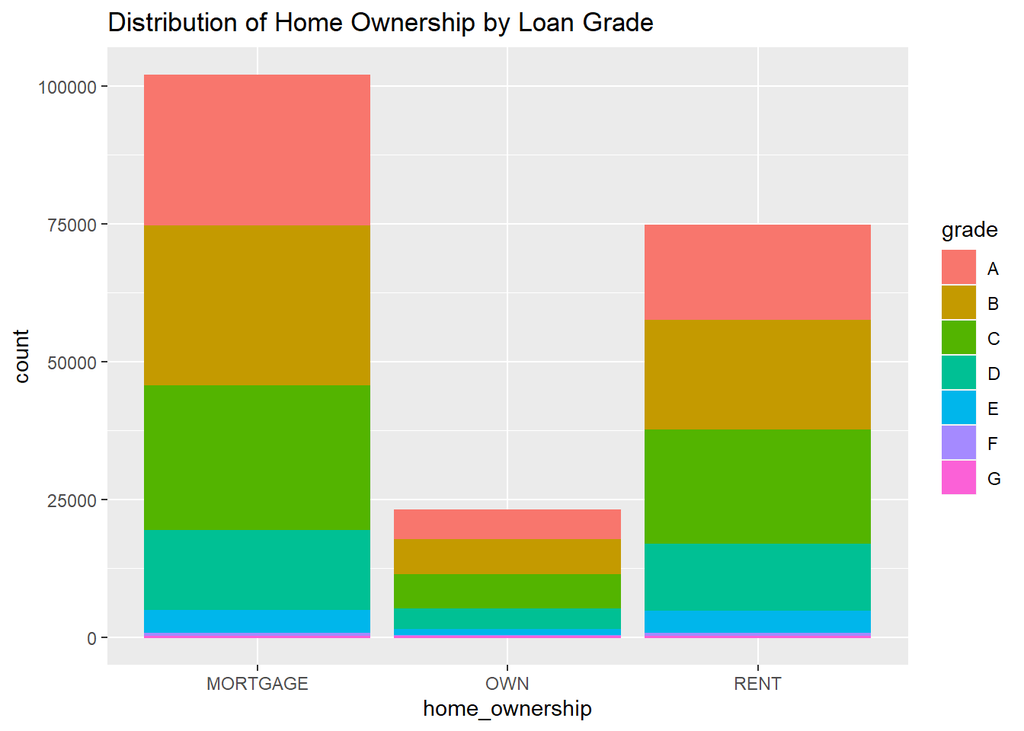

```r
ggplot(data = subset(df1, (!is.na(home_ownership) & (!home_ownership %in% c("ANY",
    "NONE", "OTHER")))), aes(home_ownership, fill = grade, color = grade)) +
    geom_bar() + labs(title = "Distribution of Home Ownership by Loan Grade")
```

```r
df %>% filter(!is.na(purpose)) %>% group_by(purpose) %>% summarise(mean_annual_inc = mean(annual_inc),
    mean_amnt_loan = mean(loan_amnt), n = n()) %>% ungroup() %>% arrange(desc(n))
```

```
## # A tibble: 13 x 4
##    purpose            mean_annual_inc mean_amnt_loan      n
##    <chr>                        <dbl>          <dbl>  <int>
##  1 debt_consolidation          83683.         17054. 108751
##  2 credit_card                 83497.         15606.  50814
##  3 home_improvement            97523.         15169.  13341
##  4 other                       81202.         11129.  12462
##  5 major_purchase              85592.         13527.   4051
##  6 medical                     75010.          9505.   2561
##  7 car                         74882.         10398.   1825
##  8 small_business             108419.         18225.   1817
##  9 house                       94950.         16272.   1783
## 10 vacation                    76316.          6579.   1333
## 11 moving                      78018.          9720.   1145
## 12 renewable_energy            76586.         11983.    116
## 13 wedding                     76000          14900       1
```

```
Q8. Mention the purpose for which highest no loans have been issued?
```

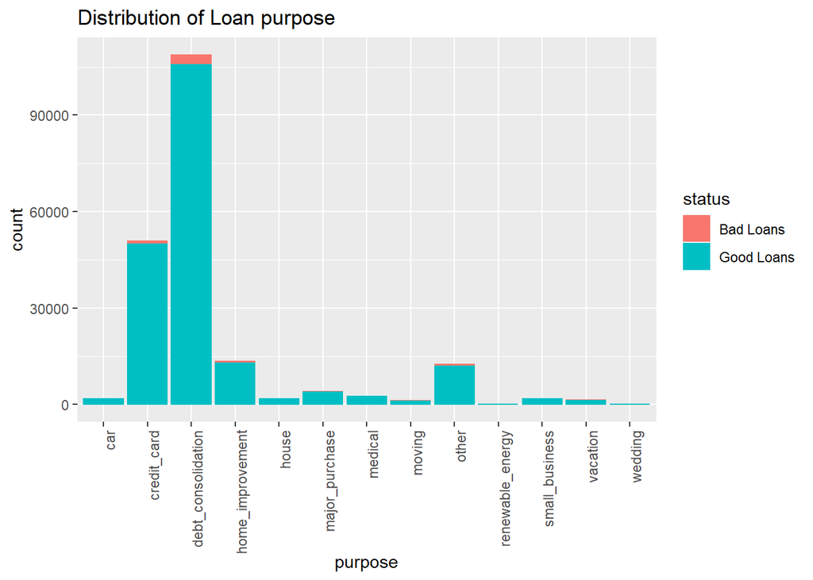

```r
ggplot(data = subset(df1, !is.na(purpose)), aes(purpose, fill = status,
    color = status)) + geom_bar() + labs(title = "Distribution of Loan purpose") +
    theme(axis.text.x = element_text(angle = 90, hjust = 1))
```

_______________________________________________________________________________________________________________________ From the Stackedbar plot, debt_consolidation and credit card purpose have been issued highest no of loans.As the count is more deliquency will be directly proportional to the count.

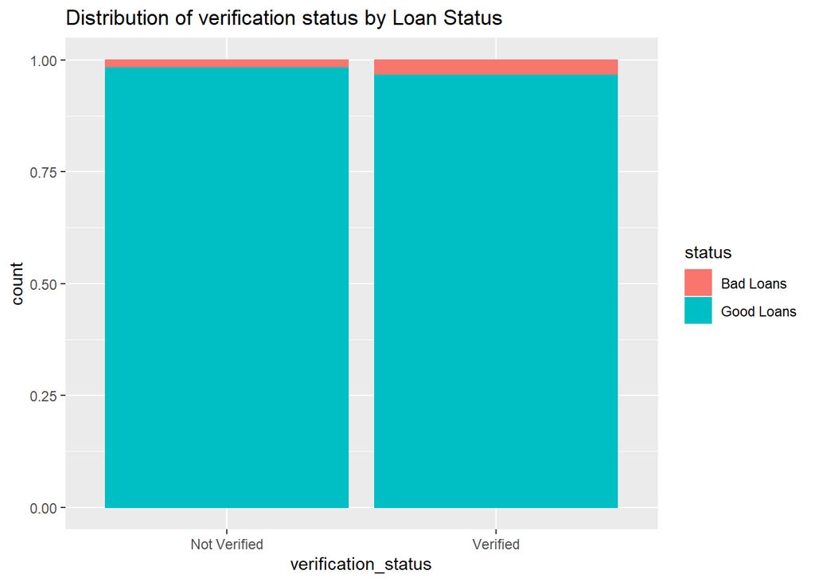

```r
ggplot(data = subset(df1, !is.na(verification_status)), aes(verification_status,
    fill = status, color = status)) + geom_bar(position = "fill") +
    labs(title = "Distribution of verification status by Loan Status")
```

_______________________________________________________________________________________________________________________ Even after the verfication, there are chances for the customer to be derogatory.

```
Table Distribution:
```

```r
pivot<-df1%>%select(home_ownership,loan_amnt,annual_inc)%>%group_by(home_ownership)%>%summarise(avgloan_amt=mean(loan_amnt),income=mean(annual_inc))

head(pivot)
```

```
## # A tibble: 4 x 3
##   home_ownership avgloan_amt income
##   <chr>                <dbl>  <dbl>
## 1 ANY                 12295. 56385.
## 2 MORTGAGE            17344. 95342.
## 3 OWN                 14902. 76363.
## 4 RENT                14124. 72328.
```

```
Here, we can observe that average income and average loan amount of mortgage category is higher compared             to other categories.
```

```r
qhpvt(df1, "grade", "home_ownership",
     c("Mean Income"="mean(annual_inc, na.rm=TRUE)", "mean loan amt"="mean(loan_amnt)"),
     formats=list("%.0f", "%.1f"))
```

[interactive chart not shown]

_______________________________________________________________________________________________________________________

This table shows the relatioship between each category of grades versus homeownership with respect to average of loan amount and annual income.

```r
qhpvt(df1, c("=", "grade"), c("status", "home_ownership"), c("Mean Income"="mean(annual_inc, na.rm=TRUE)", "mean loan amt"="mean(loan_amnt)"),
     formats=list("%.0f", "%.1f"))
```

[interactive chart not shown]

```
 The pivot chart is designed based on the distribution of Verification_status with Status with respect to             grades comparing home ownership and calculating averages income of loan amt and annual income.
```

```r
qhpvt(df1, c("=", "grade"), c("verification_status", "status","home_ownership"), c("Mean Income"="mean(annual_inc, na.rm=TRUE)", "mean loan amt"="mean(loan_amnt)"),
     formats=list("%.0f", "%.1f"))
```

[interactive chart not shown]

_______________________________________________________________________________________________________________________

```
In the above table-Not Verified, we can observe that Customers under the category "ANY" with respect to Grades       A,D,E,F and G do not possess and bad loans.
```

The below pivot table distribution shows comparison of status with respect to application status comparing average of annual income and loan amt.

```r
qhpvt(df1, "application_type", "status",
     c("Mean Income"="mean(annual_inc, na.rm=TRUE)", "mean loan amt"="mean(loan_amnt)", "countofapp"="length(application_type)"),
     formats=list("%.0f", "%.1f"))
```

[interactive chart not shown]

_______________________________________________________________________________________________________________________

```r
qhpvt(df1, "verification_status", "status",
     c("Mean Income"="mean(annual_inc, na.rm=TRUE)", "mean loan amt"="mean(loan_amnt)", "Verification Count"="length(verification_status)"),
     formats=list("%.0f", "%.1f"))
```

[interactive chart not shown]

[output not shown]

```r
qhpvt(df1, "purpose", "status",
     c("Mean Income"="mean(annual_inc, na.rm=TRUE)", "mean loan amt"="mean(loan_amnt)", "Pupose Count"="length(verification_status)"),
     formats=list("%.0f", "%.1f"))
```

[interactive chart not shown]

The pivot table above shows distribution of status with respect to purpose using mean annual Income and mean loan income Here we can bserve that wedding is the outlier. _______________________________________________________________________________________________________________________